# Computational Topology

An introduction

Author

Affiliation

Thomas Reinke

[Baylor University](https://www.baylor.edu)

Published

January 30, 2025

Abstract

Introductory notes on computational topology

# Resources

- [Wikipedia](https://en.wikipedia.org/wiki/Computational_topology)
- [Edelsbrunner Course](https://courses.cs.duke.edu//fall06/cps296.1/)
- [Hsien-Chih Chang Course & Reference](https://hcsoso.github.io/teaching/topology-f20/index.html)
  - [Algorithms for Embedded Graphs](http://monge.univ-mlv.fr/~colinde/cours/all-algo-embedded-graphs.pdf)
  - [Discrete Differential Geometry: An Applied Introduction](https://www.cs.cmu.edu/~kmcrane/Projects/DDG/paper.pdf)
  - [Elementary Applied Topology](https://www.math.upenn.edu/~ghrist/notes.html)
  - [Algebraic Topology](http://pi.math.cornell.edu/~hatcher/AT/ATpage.html)
  - [Optimization Algorithms for Planar Graphs](http://planarity.org/)
  - [Computational Topology: Lecture Notes](http://monge.univ-mlv.fr/~demesma/FullLectureNotes.pdf)

# [Computational Topology](https://www.maths.ed.ac.uk/~v1ranick/papers/edelcomp.pdf)

## Part A

### I Graphs

#### Connected Components

##### Simple graphs

**Graph**

An abstract *graph* is a pair $G = (V, E)$ consisting of a set of *vertices*, $V$, and a set of *edges*, $E$, each pair of vertices.

We can represent the vertices as points/circles and the edges with line segments or curves. Crossings of curves are allowed.

**Simple Graph**

A graph is *simple* if the edge set is a subset of the set of unordered pairs, $E \subseteq {V\choose 2}$, which means that no two edges connect the same two vertices and no edge joins a vertex to itself.

For $n = \text{card } V$ vertices, the number of edges is $m = \text{card } E \leq {n \choose 2}$. Every simple graph with $n$ vertices is a subgraph of the *complete graph*, $K_n$, that contains an edge for every pair of vertices. See Figure 1 below.

[figure not shown]

Figure 1: The complete graph with five vertices, $K_5$. It has ten edges which form five crossings if drawn as sides and diagonals of a convex pentagon. The four thick edges connect the same five vertices and form a spanning tree of the complete graph

In a simple graph, a *path* between vertices $u$ and $v$ can be described by a sequence of vertices, $u = u_0, u_1, \ldots , u_k = v$, with and edge between $u_i$ and $u_{i + 1}$ for each $0 \leq i \leq k - 1$. The *length* of this path is its number of edges, $k$. Vertices can repeat, so the path can backtrack or cross itself. The path is *simple* if the vertices in the sequence are distinct, so $u_i \neq u_j$ whenever $i \neq j$.

**Connectedness**

A simple graph is *connected* if $\exists$ a path between every pair of vertices.

A *(connected) component* is a maximal subgraph that is connected. The smallest connected graphs are the *trees*, which are characterized by having a unique simple path between every pair of vertices. Removing any one edge disconnects the tree. A *spanning tree* of $G = (V, E)$ is a tree $(V, T)$ with $T \subseteq E$. It has the same vertex set as the graph and uses a minimal set of edges necessary to be connected. This requires that the graph is connected to begin with. Indeed, a graph is connected iff it has a spanning tree. An alternative characterization of a connected graph can be based on the impossibility to cut it in two.

**Separation**

A *separation* is a non-trivial partition of the vertices, $V = U \, \dot \cup \, W$ with $U, W \neq \emptyset$, such that no edge connects a vertex in $U$ with a vertex in $W$. A simple graph is *connected* if it has no separation.

##### Topological spaces

Topologies have similarities to graphs, especially with an interest in concepts of connectedness. We will start with point sets, not specifying how near points are to another. It may be helpful to consider this an abstraction of Euclidean space, where neighborhoods are open balls around points. A *topology* on a point set $\mathbb{X}$ is a collection $\mathcal{U}$ of subsets of $\mathbb{X}$, called *open sets*, such that

1. $\mathbb{X}$ is open and the empty set $\emptyset$ is open
2. if $U_1$ and $U_2$ are open, then $U_1 \cap U_2$ is open
3. if $U_i$ is open $\forall i$ in some possibly infinite, possibly uncountable, index set, then $\bigcup\limits_{i = 1}^n U_i$ is open

The pair $(\mathbb{X}, \mathcal{U})$ is a *topological space*. Usually $\mathcal{U}$ is understood and we refer to $\mathbb{X}$ as a topological space. Since we can repeat the pairwise intersection, Condition (ii) is equivalent to requiring that common intersections of finitely many open sets are open.

A *basis* of a topology on a point set $\mathbb{X}$ is a collection $\mathcal{B}$ of subsets of $\mathbb{X}$, called *basis elements*, such that each $x \in \mathbb{X}$ is contained in at least one $B \in \mathcal{B}$ and $x \in B_1 \cap B_2$ implies there is a third basis element with $x \in B_3 \subseteq B_1 \cap B_2$. The topology $\mathcal{U}$ *generated* by $\mathcal{B}$ consists of all sets $U \subseteq \mathbb{X}$ for which $x \in U$ implies there is a basis element $x \in B \subseteq U$. This topology can be constructed explicitly by taking all possible unions of all possible finite intersections of basis sets.

An example of this is the real line, $\mathbb{X} = \mathbb{R}$, and let $\mathcal{B}$ be the collection of open intervals. This gives us the usual topology of the real line; note that the intersection of intervals $(-1/k, +1/k)$, for infinitely many integers $k \geq 1$, is the point, 0. This is not an open set which illustrates the need for restriction on finite intersections.

Often, we have sets inside of sets, $\mathbb{Y} \subseteq \mathbb{X}$, which we can borrow the topology of the latter for the former. If $\mathcal{U}$ is a topology of $\mathbb{X}$ then the collection of sets $\mathbb{Y} \cap U$, for $U \in \mathcal{U}$, is the *subspace topology* of $\mathbb{Y}$.

As an example consider the closed interval $[0, 1] \subseteq \mathbb{R}$. We have seen that the open intervals form the basis for a topology of the real line. The intersections of open intervals with $[0, 1]$ form the basis of the subspace topology of the closed interval. Note that the interval $(1/2, 1]$ is considered an open set in $[0, 1]$, but isn’t open when considered as a set in $\mathbb {R}$.

##### Continuity, paths and connectedness

A function from one topological space to another is *continuous* if the preimage of every set is open. This is derived from the same concept of continuity in calculus. Consider a function $f: \mathbb{R} \rightarrow \mathbb{R}$ that maps $(-\infty, 0]$ to $0$ and $(0, \infty)$ to $1$ is not continuous since $\forall \, 0 < \epsilon < 1$, $(-\epsilon, \epsilon)$ is open, but $f^{-1}((-\epsilon, \epsilon))$ is not.

A *path* is a continuous function from the unit interval, $\gamma : [0, 1] \rightarrow \mathbb{X}$. It *connects* the point $\gamma(0)$ to the point $\gamma(1)$ in $\mathbb{X}$. Similar to paths in graphs, we allows for self-intersections, that is, values $s \neq t$ in the unit interval for which $\gamma(s) = \gamma(t)$. If there are no self intersections, then the function is injective and the path is *simple*. We can adapt this definition to connectedness of topological spaces.

**Path-Connected**

A topological space is *path-connected* if every pair of points is connected by a path.

There is a counterpart of our second definition of connectedness. We formulate it with open sets and there is an equivalent formulation from *closed sets*, which are by definition, complements of open sets.

**Separation**

A *separation* of a topological space $\mathbb{X}$ is a partition $\mathbb{X} = U \, \dot \cup \, W$ into two non-empty, open subsets. A topological space is *connected* if there exists no separation.

Connectedness is strictly weaker than path-connectedness, although for most spaces we will encounter they are the same. For example the comb with a single tooth deleted is connected, but not path-connected.

See page 5 for full example

##### Disjoint set systems

Back to graphs & considering algorithmic question of connectedness. It is based on maintaining a disjoint set system. We will use the integers $1$ to $n$ as the names of vertices, storing each component of the graph as a subset of $[n] = \{1, 2,\ldots, n\}$. Adding edges one at a time and maintaining the systems of sets representing the components, we find that the graph is connected iff at the end, there is only one set left, $[n]$. Formulated as an abstract data type, we have two operations manipulating the system:

- FIND($i$): return the name of the set that contains $i$.
- UNION($i,j$): assuming $i$ and $j$ belong to different sets in the system, replace the two sets by their union.

We need the `find` operation to test whether $i$ and $j$ indeed belong to different sets. Each successful union operation reduces the number of sets in the system by one. Starting with $n$ singleton sets, it therefore takes $n-1$ union operations to get to a single set. Since trees connecting the $n$ vertices can be generated this way, we thus have a proof that every tree with $n$ vertices has $m = n - 1$ edges.

A typical data structure implementation stores each set as a tree embedded in a linear array, $V[1..n]$. Each node in the tree is equipped with a pointer to its *parent*, except for the *root*, which has no parent; see Figure 2 and Figure 3 below . Who is the parent of whom isn’t important so long as the vertices are connected in a single tree. We can implement the `find` operation by traversing the tree upward until the root is reached, reporting the root as the name of the set.

[figure not shown]

Figure 2: Two trees representing two disjoint sets

[figure not shown]

Figure 3: storing the two trees in a linear array using an arbitrary ordering of the nodes.

```
int FIND(i)
    if V[i].parent ≠ null then return Find(V[i].parent)
                               else return i
    endif
```

If $i$ is not the root, then we find the root recursively and finally return it. Otherwise, $i$ is returned as the root. We can then implement the `union` operation by linking one root to the other.

```
void UNION(i, j)
    x = FIND(i); y = FIND(j);
    if x ≠ y then V[x].parent = y endif
```

After making sure the two sets are different, we assign one root as the parent of the other.

##### Improving the running time

This is not a very efficient method, especially for long paths that may be traversed repeatedly. We prevent this by always linking the smaller tree to the larger one.

```
void UNION(i,j)
    x = FIND(i); y = FIND(j);
    if x ≠ y then if V[x].size > V[y].size then x ↔ y endif;
                  V[x].parent = y
    endif
```

Now a tree of $k$ nodes cannot have paths longer than $\log_2 k$ edges, since the size of the subtree grows by at least a factor of two each time we pass the parent. To improve the efficiency even more, we compress paths whenever we traverse them. We also assume that roots are identified by pointing to themselves.

```
int FIND(i)
    if V[i].parent ≠ i then
        return V[i].parent = FIND(V[i].parent)
    endif;
    return i
```

If $i$ is not the root, then the function recursively finds the root, makes it the parent of $i$, reports the root, and exits. Otherwise, the function reports $i$ as the root and exits.

In analyzing the algorithm, we are interested in the running-time for executing a sequence of $m$ union and find operations. Finding tight bounds is a difficult problem. For $n$ vertices, the running-time is never more than $O(m\alpha (n))$, where $\alpha(n)$ is the slow growing inverse of the [Ackermann function](https://en.wikipedia.org/wiki/Ackermann_function). Eventually, $\alpha(n)$ goes to infinity, but to reach even beyond five, we need an astronomically large number of vertices, larger than electrons in the universe. So for practical purposes, the algorithm takes constant average time per operation, but theoretically not true.

#### Curves in the Plane

Previously, paths were used to merge points into connected components. However, to consider connectivity beyond components, we will need different maps.

##### Closed curves

We will consider two types of (connected) curves, *paths* and *closed curves*. Recall that paths are continuous maps from $[0,1]$ to $\mathbb{X}$. Occasionally a closed curve will defined as a path where $0$ and $1$ are mapped to the same point. Usually, we define a closed curve to be a map from the unit circle, $\gamma : \mathbb{S}^1 \rightarrow \mathbb{X}$, where $\mathbb{S}^1 = \{x \in \mathbb{R} \, | \, \Vert x \Vert = 1\}$. This emphasizes the differences between in properties of the two topological spaces, since the interval and unit circle are different topological spaces. To be precise, two topological spaces are *homeomorphic* or *topologically equivalent* if there exists a continuous bijection from one space to the other whose inverse is also continuous. A map with these properties is a *homeomorphism*. Note that a homeomorphism between two spaces gives a bijection between their open sets. The unit interval and the unit circle are not homeomorphic. Removing a midpoint from the interval results in two components, whereas the circle will remain connected. This negates the existence of a bijection that is continuous in both directions.

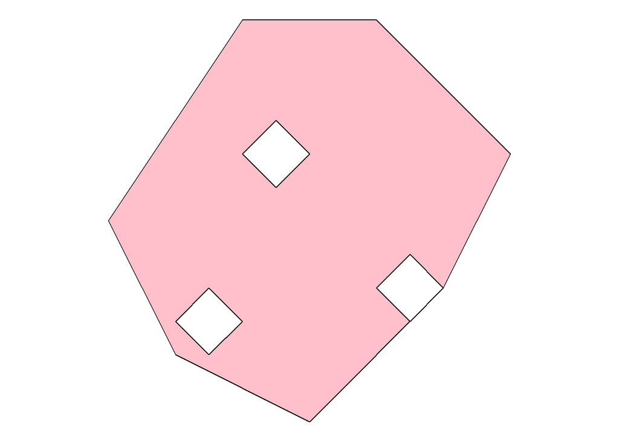

#### Knots & Links

#### Planar Graphs

### II Surfaces

#### Two-Dimensional Manifolds

#### Searching a triangulation

#### Self-Intersections

#### Surface Simplification

### III Complexes

#### Simplical Complexes

#### Convex Set Systems

#### Delaunnay Complexes

#### Alpha Complexes

## Part B

### IV Homology

#### Homology Groups

#### Matrix Reduction

#### Relative Homology

#### Exact Sequences

### V Duality

#### Cohomology

#### Poincare Duality

#### Intersection Theory

#### Alexander Duality

### VI Morse Functions

#### Generic Smooth Functions

#### Transversality

#### Piecewise Linear Functions

#### Reeb Graphs

## Part C

### VII Persistence

#### Persistent Homology

#### Efficient Implementations

#### Extended Persistence

#### Spectral Sequences

### VIII Stability

#### Times Series

#### Stability Theorems

#### Length of a Curve

#### Bipartite Graph Matching

### IX Applications

#### Image Segmentation

#### Elevation

#### Gene Expression

#### Local Homology for Plant Root Architecture

## Part D

### X Open Problems

#### Complexity of Reidmeister Moves

#### Shelling a 3-ball

#### Geometric Realization of 2-manifolds

#### Embedding in Three Dimensions

#### Equipartion in Four Dimensions

#### Running-time of Matrix Reduction

#### Multi-parameter Persitence

#### Unfolding PL Critical Points

#### PL in the Limit

#### Counting Halving Sets